# DSA5403 Lab2 Chapter 3, R and distributional theory

## Task 2

**Learn how to use the four basic distributional functions dpois, pstem, rstem, qstem**

1. Suppose that X~Pois(lamda). Use R and the above function types to answer the following.
- 1. Find P(X=4|lamda=3)

```r
dpois(4, 3)
```

```
## [1] 0.1680314
```

- 2. Find P(X<=4|lamda=3)

```r
ppois(4,3,lower.tail=T)
```

```
## [1] 0.8152632
```

- 3. Find P(X>4|lamda=3)

```r
1-ppois(4,3) #method 1
```

```
## [1] 0.1847368
```

```r
1-sum(dpois(0:4,3)) #method 2
```

```
## [1] 0.1847368
```

```r
ppois(4,3,lower.tail = F) #method 3
```

```
## [1] 0.1847368
```

- 4. Find x so that P(X<=x|lamda=3)=0.9997077

```r
myfun=function(x,lam,prob){
  prob=1-(lam^x*exp(-lam))/factorial(x)
  return(x)
}
#myfun(x,3,0.9997077)
x=10
```

- 22. Create a sample of size 100 from a Poisson distribution that has parameter lamda=3, Store in an object.

```r
set.seed(124)
Fst=rpois(100,3)
```

- 6. Make a second sample of size 100 from a Poisson that has parameter lamda=6, store in an object

```r
set.seed(124)
Snd=rpois(100,6)
```

2. Make boxplots of the random samples you made above.
- 1. We will make a data frame of the data. Call the first group “Fst” and the second group “Snd”. All data in the first group have to have “Fst” associated with them etc.

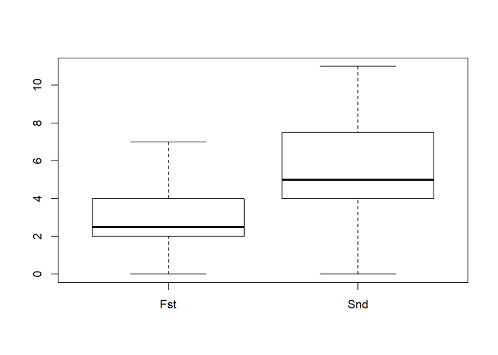

```r
df=data.frame(Bin =c(Fst,Snd), Lab=rep(c("Fst","Snd"),c(100,100))) # create a datafame "df" with "Fst" and "Snd"
boxplot(data.frame(Fst,Snd))
```

- 2. See Laboratory2.R for some exemplar code using ggplot

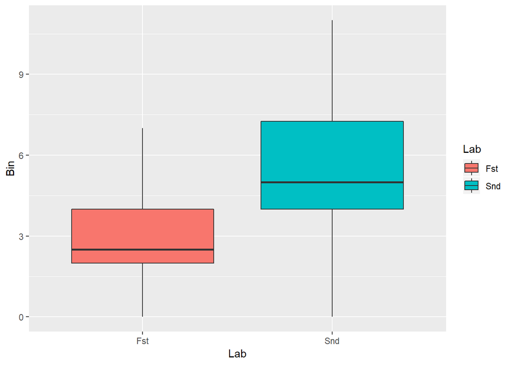

```r
g = ggplot(df, aes(x = Lab, y = Bin, fill = Lab)) +
  geom_boxplot()
g #boxplot withe dataframe we created
```

3. Make violin plots of the same using ggplot

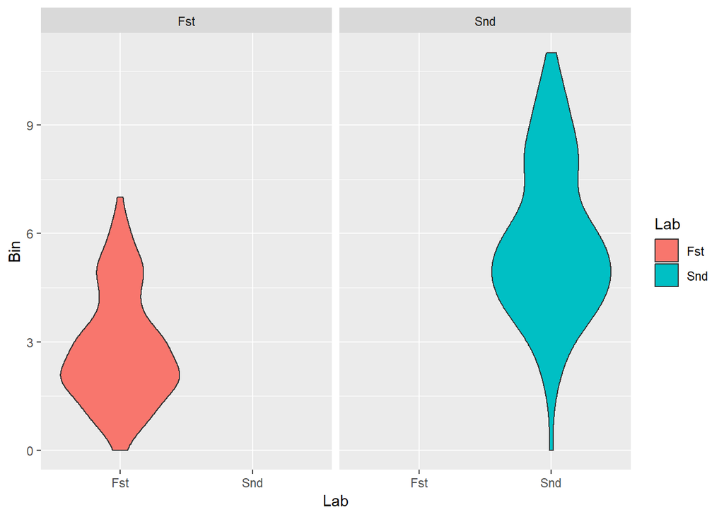

```r
e = ggplot(df, aes(x = Lab, y=Bin, fill = Lab)) +
  geom_violin(aes(y = Bin)) +facet_wrap(~Lab)
e # violin plot
```